# Sample Analysis of Station WSC.08HA011 - Cowichan River near Duncan

Carl James Schwarz

2017-07-06

This will demonstrate a sample analysis of the stream discharge data from station WSC.08HA011 (Cowichan River near Duncan) which is provided as a sample dataset (WSC.08HA011) with this package. The basin has an area of 826 km**2. While the data fram runs from 1900 onwards, data was only populated in this example starting in 1965 onwards.

## Loading the data and some initial plots

We first load the package, load the data and look at the first few rows starting in 1965.

```r
library(ggplot2)
library(plyr)       # split-apply-combine paradigm
library(reshape2)   # for melting and casting

library(BCWaterDischargeAnalysis)


data(WSC.08HA011)
head( WSC.08HA011[ as.numeric(format(WSC.08HA011$Date, "%Y"))==1965,])
```

```
##             Date    Q
## 23742 1965-01-01 46.4
## 23743 1965-01-02 45.0
## 23744 1965-01-03 44.5
## 23745 1965-01-04 39.6
## 23746 1965-01-05 38.2
## 23747 1965-01-06 36.5
```

**Notice that the flow dataframe MUST have two variables: `Date` and `Q` - the daily discharge value.**

[output not shown]

Other variables in the data frame will be ignored.

Missing values can be entered in two ways. First, the date with the missing value of `Q` can be dropped from the data frame. Second, the value of `Q` can be set to missing (NA). Both methods can be used together. An example of the impact of missing values occurs in the second half of this vignette.

We now set the variables limiting the years for which the analysis should be done and setting up other needed variables for the analysis.

```r
Station.Code <- 'WSC-08HA011'
Station.Name <- 'Cowichan River near Duncan'
Station.Area <- 826    # square km's

start.year   <- 1965  # when do you want the analysis to start at.
end.year     <- 2012  # what is last year with complete data
```

## Preliminary screening

Before analyzing the discharge values, you should do some preliminary screening to check for unusual data values, count missing values etc.

Here are some suggestions:

```r
cat("Number of illegal date values ", sum(is.na(WSC.08HA011$Date)), "\n")
```

```
## Number of illegal date values  0
```

```r
WSC.08HA011[ is.na(WSC.08HA011$Date),]     # sorry Microsoft, but feb 29 1900 is NOT a leap year
```

```
## [1] Date Q
## <0 rows> (or 0-length row.names)
```

```r
dim(WSC.08HA011)  # size before removing illegal dates
```

```
## [1] 42734     2
```

```r
WSC.08HA011 <- WSC.08HA011[ !is.na(WSC.08HA011$Date),]
dim(WSC.08HA011)  # size after removing illegal dates
```

```
## [1] 42734     2
```

```r
# get a simple summary of the data
WSC.08HA011$Year <- as.numeric(format(WSC.08HA011$Date, "%Y")) # add the year to the data frame
# Table of simple statistics by year to help check for outliers, etc
WSC.08HA011.sum <- plyr::ddply(WSC.08HA011[ WSC.08HA011$Year >= start.year & WSC.08HA011$Year <=end.year,], "Year", plyr::summarize,
         n.days   = length(Year),
         n.Q      = sum (!is.na(Q)),
         n.miss.Q = sum ( is.na(Q)),
         min.Q    = min (Q, na.rm=TRUE),
         max.Q    = max (Q, na.rm=TRUE),
         mean.Q   = mean(Q,na.rm=TRUE),
         sd.Q     = sd  (Q,na.rm=TRUE))
WSC.08HA011.sum
```

```
##    Year n.days n.Q n.miss.Q min.Q max.Q   mean.Q     sd.Q
## 1  1965    365 365        0  3.54 196.0 47.72625 44.55059
## 2  1966    365 365        0  5.80 362.0 60.32545 65.58664
## 3  1967    365 365        0  4.11 213.0 61.70992 53.65439
## 4  1968    366 366        0  5.10 450.0 69.52503 71.15098
## 5  1969    365 365        0  4.98 150.0 47.50655 35.52722
## 6  1970    365 365        0  4.25 153.0 36.84767 34.33385
## 7  1971    365 365        0  6.00 187.0 55.62266 39.62329
## 8  1972    366 366        0  5.83 425.0 53.93230 59.41003
## 9  1973    365 365        0  3.11 337.0 53.33545 64.81365
## 10 1974    365 365        0  3.28 343.0 69.46066 64.42318
## 11 1975    365 365        0  6.43 345.0 66.59186 65.38940
## 12 1976    366 366        0  4.62 165.0 47.77153 37.67202
## 13 1977    365 365        0  4.16 233.0 47.69573 47.43126
## 14 1978    365 365        0  4.64 101.0 30.25252 21.66569
```

[output cut: 34 more lines]

We see that there are no missing values in any of the year between the start and end year. This report is also generated by the `compute.Q.stat.annual()` function.

Let’s visuallize some of the statistics overtime

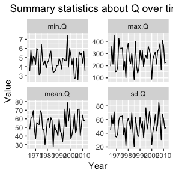

```r
# visuallize the min, max, and mean
plotdata <- reshape2::melt(WSC.08HA011.sum,
             id.var='Year',
             measure.var=c("min.Q","max.Q","mean.Q","sd.Q"),
             variable.name='Statistic',
             value.name='Value')
ggplot2::ggplot(data=plotdata, aes(x=Year, y=Value))+
  ggtitle("Summary statistics about Q over time")+
  theme(plot.title = element_text(hjust = 0.5))+
  geom_line()+
  facet_wrap(~Statistic, ncol=2, scales="free_y")
```

## Computing the Annual Statistics (on calendar and water year)

We compute the plethora of annual statistics

```r
stat.annual <- compute.Q.stat.annual(
                          Station.Code  =Station.Code,
                          Station.Area  =Station.Area,
                          flow          =WSC.08HA011,
                          start.year    =start.year,
                          end.year      =end.year)
```

This will create a list object with many elements:

```r
names(stat.annual)
```

```
##  [1] "Q.flow.summary"      "Q.stat.annual"       "Q.stat.annual.trans"
##  [4] "dates.missing.flows" "file.cy.stat.csv"    "file.wy.stat.csv"
##  [7] "file.stat.trans.csv" "file.stat.trend.pdf" "file.cumdepart.pdf"
## [10] "file.summary.csv"    "file.lowflow.csv"    "na.rm"
## [13] "Version"             "Date"
```

This has many, many statistics some of which are shown below:

```r
head(stat.annual$Q.stat.annual[, 1:10])
```

```
##   Year CY_MIN_01Day_SW CY_MINDOY_01Day_SW CY_MIN_03Day_SW
## 1 1965            3.54                276              NA
## 2 1966            5.80                215        5.936667
## 3 1967            4.11                243        4.110000
## 4 1968            5.10                219        5.223333
## 5 1969            4.98                228        4.980000
## 6 1970            4.25                203        4.343333
##   CY_MINDOY_03Day_SW CY_MIN_07Day_SW CY_MINDOY_07Day_SW CY_MIN_30Day_SW
## 1                 NA              NA                 NA              NA
## 2                224        6.305714                225        6.445667
## 3                256        4.320000                269        4.652333
## 4                220        5.258571                223        6.569000
## 5                238        5.071429                240        5.357667
## 6                204        4.642857                206        5.035667
##   CY_MINDOY_30Day_SW CY_MIN_DAILY_SW
## 1                 NA            3.54
## 2                244            5.80
## 3                270            4.11
## 4                237            5.10
## 5                256            4.98
## 6                230            4.25
```

Notice the default acton (refer to the `missing-data` vignette) is to propagate missing values. Despite a complete data record starting in 1965, we made this example have no data prior to (and including) 1964-12-31. This implies that a three-day rolling average that includes 1964-12-31 cannot be computed which gives rise to missing values for the 3-day rolling average minimum flow for the first few days in 1965. This also occurs for other rolling averages that include any 1964 data such as the water year computation for the 1965 water year which started on 1964-10-01.

These statistics can be then processed as you desire.

As well, the default arguments will also create several `.csv` files with the summary statistics and a `.pdf` file with the trends plotted over time in the directory you run the code in. The file names are given in the list object:

```r
stat.annual$file.stat.csv
```

[output not shown]

```r
stat.annual$file.stat.trans.csv
```

```
## [1] "./WSC-08HA011-annual-summary-stat-trans.csv"
```

```r
stat.annual$file.stat.trend.pdf
```

```
## [1] "./WSC-08HA011-annual-trend.pdf"
```

## Computing the long term summary statistics

We compute the long term summary statistics

```r
stat.longterm <- compute.Q.stat.longterm(
                          Station.Code =Station.Code,
                          #Station.Area =Station.Area,  # removed in recent version
                          flow         =WSC.08HA011,
                          start.year   =start.year,
                          end.year     =end.year)
```

This will create a list object with many elements:

```r
names(stat.longterm)
```

```
##  [1] "Q.cy.stat.longterm"       "Q.cy.stat.longterm.trans"
##  [3] "file.cy.stat.csv"         "file.cy.stat.trans.csv"
##  [5] "Q.wy.stat.longterm"       "Q.wy.stat.longterm.trans"
##  [7] "file.wy.stat.csv"         "file.wy.stat.trans.csv"
##  [9] "na.rm"                    "Version"
## [11] "Date"
```

This has the long term summary statistics (mean, min, max, etc) by month some of which are shown below:

```r
head(stat.longterm$Q.cy.stat.longterm)
```

```
##   Month      Mean Median Maximum Minimum
## 5   Jan 110.46828  98.65   450.0   15.60
## 4   Feb  92.69174  82.90   303.0   14.70
## 8   Mar  77.38508  68.85   359.0   15.80
## 1   Apr  57.23731  52.40   154.0    8.67
## 9   May  35.27665  31.00   121.0    6.47
## 7   Jun  18.18226  13.60    73.4    2.99
```

Because these statistics are computed on the calendar year basis and there were no missing values in the period of record, there are no missing summary statistics (see the `missing-data` vignette for more details). These statistics can be then processed as you desire.

As well, the default arguments will also create several `.csv` file with the summary statistics and a `.pdf` file with the trends plotted over time in the directory you run the code in. The file names are given in the list object:

```r
stat.longterm$file.cy.stat.csv
```

```
## [1] "./WSC-08HA011-longterm-cy-summary-stat.csv"
```

```r
stat.longterm$file.cy.stat.trans.csv
```

```
## [1] "./WSC-08HA011-longterm-cy-summary-stat-trans.csv"
```

## Computing the long term percentile statistics

We compute the long term percentile statistics

```r
percentile.longterm <- compute.Q.percentile.longterm(
                          Station.Code=Station.Code,
                          #Station.Area=Station.Area,
                          flow        =WSC.08HA011,
                          start.year  =start.year,
                          end.year    =end.year)
```

This will create a list object with many elements:

```r
names(percentile.longterm)
```

```
##  [1] "Q.cy.percentile.stat"       "Q.cy.percentile.stat.trans"
##  [3] "Q.wy.percentile.stat"       "Q.wy.percentile.stat.trans"
##  [5] "file.cy.stat.csv"           "file.cy.stat.trans.csv"
##  [7] "file.wy.stat.csv"           "file.wy.stat.trans.csv"
##  [9] "na.rm"                      "Version"
## [11] "Date"
```

```r
head(percentile.longterm$Q.cy.percentile.stat)
```

```
##   Month     P01     P02    P05   P10   P15    P20    P25   P30     P35
## 5   Jan 21.8740 25.2000 31.480 40.41 49.60 58.600 65.800 70.81 78.2000
## 4   Feb 23.2550 29.7200 36.950 43.90 49.60 54.900 60.000 64.10 68.5250
## 8   Mar 20.3960 24.5740 29.235 36.07 41.91 47.200 51.300 55.40 58.9450
## 1   Apr 13.4000 16.0120 23.490 28.48 32.30 35.800 38.575 41.30 43.6000
## 9   May  7.4122  8.7748  9.867 12.20 14.20 16.100 18.350 21.31 23.7000
## 7   Jun  3.9500  4.6200  5.580  6.28  6.55  6.948  7.580  8.16  9.0965
##     P40    P45   P50     P55    P60     P65    P70     P75    P80     P85
## 5 84.94 92.215 98.65 106.000 112.00 120.550 129.00 141.000 152.60 169.900
## 4 73.10 77.275 82.90  89.150  95.40 101.000 107.00 114.000 122.00 133.000
## 8 62.60 65.115 68.85  71.385  74.84  79.000  85.40  92.900 101.00 112.950
## 1 45.66 48.655 52.40  56.000  59.70  63.700  68.00  72.425  77.34  85.000
## 9 26.40 29.000 31.00  33.400  36.62  40.055  43.70  49.000  54.30  60.295
## 7 10.70 12.000 13.60  15.200  16.84  18.800  20.63  23.025  26.82  32.215
##      P90     P95    P98     P99
## 5 194.00 239.650 282.26 321.000
## 4 154.00 186.000 229.80 245.450
## 8 132.30 161.650 188.26 209.520
## 1  93.91 107.000 120.00 131.610
## 9  65.83  72.800  79.13  84.082
## 7  40.40  49.005  57.20  63.954
```

Because these statistics are computed on the calendar year basis and there were no missing values in the period of record, there are no missing summary statistics (see `missing-data` vignette for more details). Similar statistics are available on the water year basis.

These statistics can be then processed as you desire.

As well, the default arguments will also create several `.csv` file with the summary statistics for the calendar and water years and a `.pdf` file with the trends plotted over time in the directory you run the code in. The file names are given in the list object:

```r
percentile.longterm$file.cy.stat.csv
```

```
## [1] "./WSC-08HA011-longterm-cy-percentile-stat.csv"
```

```r
percentile.longterm$file.cy.stat.trans.csv
```

```
## [1] "./WSC-08HA011-longterm-cy-percentile-stat-trans.csv"
```

## Computing a volume frequency analysis

We compute the volume frequency analysis

```r
vfa.analysis <- compute.volume.frequency.analysis(
                      Station.Code   =Station.Code,
                      flow           =WSC.08HA011,
                      start.year     =start.year,
                      end.year       =end.year)
```

Because these statistics are computed on the calendar year basis and there were no missing values in the period of record, there was no impact of missingness on the computations.

This will create a list object with many elements:

```r
names(vfa.analysis)
```

```
##  [1] "start.year"              "end.year"
##  [3] "use.water.year"          "use.max"
##  [5] "roll.avg.days"           "Q.stat"
##  [7] "Q.stat.trans"            "plotdata"
##  [9] "prob.plot.position"      "freqplot"
## [11] "fit.distr"               "fit"
## [13] "fitted.quantiles"        "fitted.quantiles.trans"
## [15] "file.stat.csv"           "file.stat.trans.csv"
## [17] "file.plotdata.csv"       "file.quantile.csv"
## [19] "file.quantile.trans.csv" "file.frequency.plot"
## [21] "Version"                 "Date"
```

A frequency plot is created as an object in the list, and also written to the directory

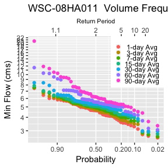

```r
vfa.analysis$freqplot
```

The quantiles from the fitted distribution (the default is a Pearson Log III distribution) are also computed:

```r
vfa.analysis$fitted.quantiles.trans
```

```
##    distr  prob     Return Q001-avg Q003-avg Q007-avg Q015-avg Q030-avg
## 1   PIII 0.010 100.000000 2.437537 2.544397 2.611767 2.738193 2.880917
## 2   PIII 0.050  20.000000 2.976171 3.108230 3.228087 3.378068 3.513155
## 3   PIII 0.100  10.000000 3.289789 3.433166 3.579166 3.739922 3.878317
## 4   PIII 0.200   5.000000 3.692997 3.846881 4.020310 4.191558 4.344346
## 5   PIII 0.500   2.000000 4.529539 4.689240 4.893066 5.073719 5.297933
## 6   PIII 0.800   1.250000 5.436928 5.575970 5.766214 5.938405 6.310295
## 7   PIII 0.900   1.111111 5.932125 6.046993 6.207631 6.367395 6.852380
## 8   PIII 0.950   1.052632 6.348495 6.435532 6.558702 6.704024 7.302151
## 9   PIII 0.975   1.025641 6.713263 6.770038 6.850824 6.980675 7.691466
## 10  PIII 0.980   1.020408 6.822247 6.868883 6.935265 7.060010 7.806904
## 11  PIII 0.990   1.010101 7.139578 7.153741 7.173624 7.282293 8.140661
##     Q060-avg  Q090-avg
## 1   3.263051  3.897470
## 2   3.783335  4.268720
## 3   4.116313  4.544873
## 4   4.582942  4.976665
## 5   5.721311  6.225931
## 6   7.303262  8.382377
## 7   8.373320 10.107665
## 8   9.419517 12.002292
## 9  10.469621 14.113078
## 10 10.811199 14.845393
## 11 11.888817 17.304941
```

These statistics can be then processed as you desire.

As well, the default arguments will also create several `.csv` file with the summary statistics and a `.pdf` file with the trends plotted over time in the directory you run the code in. The file names are given in the list object:

```r
vfa.analysis$file.stat.csv
```

```
## [1] "./WSC-08HA011-annual-vfa-stat.csv"
```

```r
vfa.analysis$file.quantile.csv
```

```
## [1] "./WSC-08HA011-annual-vfa-quantiles.csv"
```

```r
vfa.analysis$file.frequency.plot
```

```
## [1] "./WSC-08HA011-annual-vfa-frequency-plot.pdf"
```